# Inference with Raster Spatial Data with R

Bas Machielsen

2023-05-03

## Importing the Data

First, I load the necessary libraries:

[output not shown]

## Data Sources

I’ll also be using a variety of data sources. Here, I want to give a short overview of the data sources used in the original paper, and alternative data sources, as well as R packages that make it easy to access these data:

**Dependent variables**:

- [Gridded Population of the World](https://sedac.ciesin.columbia.edu/data/collection/gpw-v4)
- [NOAA Nightlights](https://github.com/walshc/nightlights)
- [Alternative Nightlights package](https://github.com/JakobMie/nightlightstats)
- [Website with Graphical User Interface](https://eogdata.mines.edu/products/vnl/#annual_v2)
- [The Oxford Roman Economy Project](http://oxrep.classics.ox.ac.uk/databases/mines_database/): Data on Settlements in 500AD
- `osmdata` R package [vignette](https://cran.r-project.org/web/packages/osmdata/vignettes/osmdata.html): Data on contemporary roads

**Miscellaneous data**:

- [Digital Atlas of the Roman Empire](https://imperium.ahlfeldt.se/): used to retrieve *Oppidum* and Roman settlements through an API Interface
- [Other Roman Empire Datasets](https://projectmercury.eu/datasets/)

**Independent variables**:

- **Major Roman Roads**: From the `cawd` package:
- [The Oxford Roman Economy Project](http://oxrep.classics.ox.ac.uk/databases/mines_database/): Data on Roman Mines
- [Terrain ruggedness](https://diegopuga.org/data/rugged/)
- `elevatr` R package [Vignette](https://cran.r-project.org/web/packages/elevatr/vignettes/introduction_to_elevatr.html#Get_Raster_Elevation_Data): Elevation data through R
- [Caloric Suitability Index](https://ozak.github.io/Caloric-Suitability-Index/):
- [Agricultural Suitability](https://cran.r-project.org/web/packages/ALUES/index.html): Agricultural Land Use Evaluation System
- [The `climateR` package](https://rpubs.com/ials2un/trrclmt): Package with access to climate data
- [The `climatrends` package](https://agrdatasci.github.io/climatrends/): Alternative package with access to climate data

## Get the roads and the borders

The borders can be found on [this repository](https://github.com/AWMC/geodata/blob/master/Cultural-Data/political_shading/roman_empire_ce_117_extent/roman_empire_ce_117_extent.geojson). I’ll be using only a small subset of the data to keep down computational and memory load.

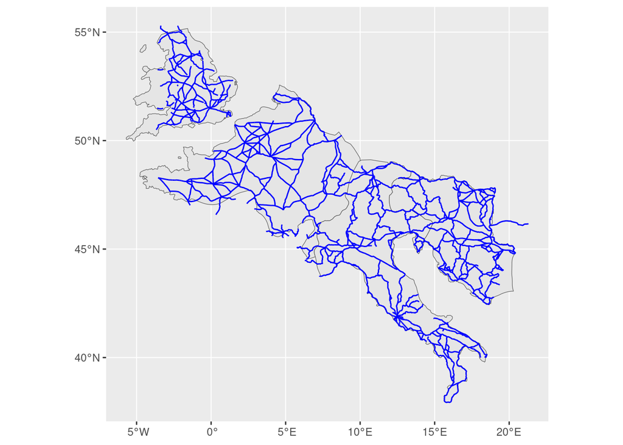

```r
ggplot() + geom_sf(data=borders) +
  geom_sf(data=roads, color='blue')
```

## Import and filter nightlight density

- The following has to be run only once to recreate the nightlights data.

```r
# load the raster dataset
raster_data <- raster("./nightlights/VNL_v21_npp_2014_global_vcmslcfg_c202205302300.average_masked.dat.tif")
# Crop the dataset:
raster_data <- crop(x = raster_data, y = borders)
# Or
#raster_data <- crop(x = raster_data, y = extent(borders))

# Limit the max light intensity
raster_data <- raster_data |> clamp(upper = 50)
# Crop the data:
#raster_data <- raster::mask(raster_data,
#                                 mask = as_Spatial(st_bbox(borders) |> st_as_sfc()))
# Or:
raster_data <- raster::mask(raster_data ,mask=borders)

# Write output
writeRaster(raster_data, "./nightlights/nightlights_re.tif", overwrite=TRUE)
```

We can now use the imported file:

```r
raster_data <- raster::raster("./nightlights/nightlights_re.tif")
crs <- raster_data@crs
```

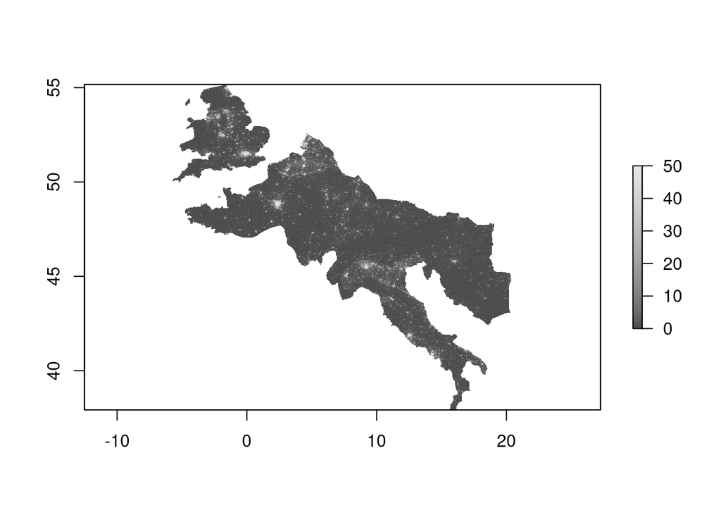

```r
plot(raster_data, col = gray.colors(100))
```

## Compute nightlight density per 0.5x0.5

Now, we can set out to compute the nightlight density per 0.5x0.5 latitude x longitude area.

```r
# set the resolution of the grid
resolution <- 0.5
# convert raster to points
raster_points <- raster::rasterToPoints(raster_data)
# round the coordinates to the nearest 0.5 degrees
raster_points[,1:2] <- round(raster_points[,1:2]/resolution)*resolution
# convert to SpatialPointsDataFrame
raster_sp <- sp::SpatialPointsDataFrame(raster_points[,1:2],
                                        data.frame(value=raster_points[,3]))
# compute mean value for each cell
raster_mean <- raster::aggregate(raster_sp, by=list(round(raster_sp@coords[,1]/resolution),
                                                    round(raster_sp@coords[,2]/resolution)),
                                 FUN=mean)

# convert back to raster
raster_mean_raster_nl <- raster::rasterFromXYZ(data.frame(raster_mean),
                                            crs=raster_data@crs,
                                            res=resolution)
```

Now our raster looks like this:

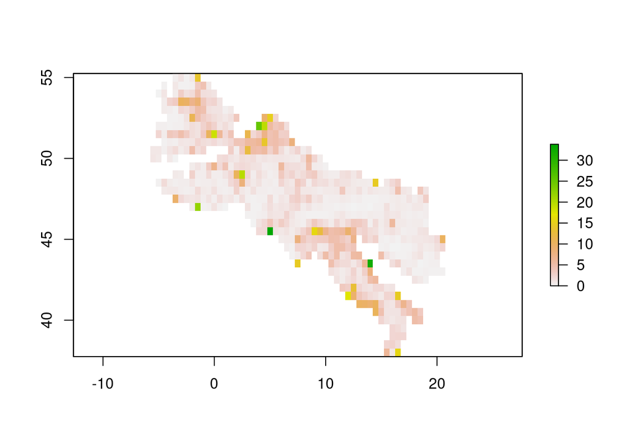

```r
plot(raster_mean_raster_nl$value)
```

Our next job is to calculate the road density over these same areas. In order to do so, we have to create a buffer around the roads to make sure it has an area. In line with the paper, we’ll pick an area of 5 kilometer:

```r
# create a 5km buffer around the vector dataset
buffer_data <- st_buffer(roads, dist = 5000)
# convert the buffer to a raster dataset
buffer_raster <- rasterize(buffer_data, raster_data, background=0)
# reclassify the buffer_raster
buffer_raster <- reclassify(buffer_raster,
                            matrix(c(0.001, 10000, 1),
                                   ncol=3, byrow = TRUE))

# mask the buffer to be zero only if inside the empire borders but without road
buffer_raster <- mask(buffer_raster, mask = raster_data)

# convert raster to points
raster_points <- raster::rasterToPoints(buffer_raster)
```

Now that we have the rasterized buffered roads data, we can aggregate it by 0.5x0.5 latitude x longitude area, and calculate the percentage of area covered by roman road. We reclassified the area such that roads have a value of 1 at a pixel where there is a road, 0 otherwise. Because of this, we can calculate the density by taking the mean per area.

```r
# round the coordinates to the nearest 0.5 degrees
raster_points[,1:2] <- round(raster_points[,1:2]/resolution)*resolution
# convert to SpatialPointsDataFrame
raster_sp <- sp::SpatialPointsDataFrame(raster_points[,1:2],
                                        data.frame(value=raster_points[,3]))

# compute mean value for each cell
raster_mean <- raster::aggregate(raster_sp, by=list(round(raster_sp@coords[,1]/resolution),
                                                    round(raster_sp@coords[,2]/resolution)),
                                 FUN=mean)
```

Finally, we put this mean per area back into a raster and plot:

```r
# convert back to raster
raster_mean_raster_roads <- raster::rasterFromXYZ(data.frame(raster_mean),
                                            crs=crs,
                                            res=resolution)
```

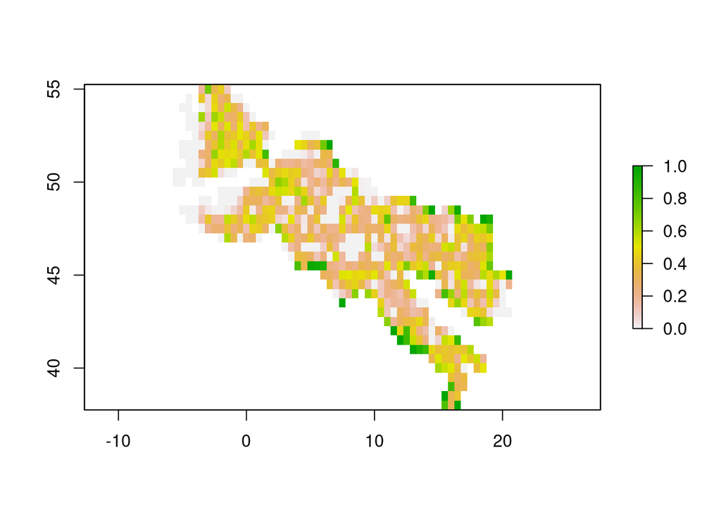

```r
plot(raster_mean_raster_roads$value)
```

## Analysis

The analysis now involves stacking the data from `raster_mean_raster_nl` (the nightlights data) and `raster_mean_raster_roads` involving the roads and regression the one on the other. Let’s implement this and then conduct a short analysis. The relevant data is in the fourth column of the raster data. Potentially, we could also merge the data with other data.frames based on the other columns.

```r
data <- data.frame(
  nightlights = raster_mean_raster_nl@data@values[,4],
  roads = raster_mean_raster_roads@data@values[,4])
```

Now, we estimate the influence of Roman road density on nightlight activity:

```r
library(fixest); library(modelsummary)

fixest::feols(nightlights ~ log(1+roads), data = data) |>
  msummary(stars = T, vcov = 'robust')
```

|  | (1) |
| --- | --- |
| (Intercept) | 1.030*** |
|  | (0.239) |
| log(1 + roads) | 5.061*** |
|  | (1.062) |
| Num.Obs. | 687 |
| R2 | 0.066 |
| R2 Adj. | 0.065 |
| AIC | 3624.8 |
| BIC | 3633.9 |
| RMSE | 3.37 |
| Std.Errors | HC1 |

+ p < 0.1, * p < 0.05, ** p < 0.01, *** p < 0.001